# Splines with Multiple Imputation

Kevin Chen

## Quick review of multiple imputation

Here, we briefly review some material presented by Murray and others (2018). Let $Y_i$ be some variable corresponding to the $i$th unit. For some units, the value of this variable is missing. When we know the mechanism by which $Y_i$ is missing, we may use multiple imputation (MI) to estimate the value of some (scalar) estimand $Q$, possibly a function of $Y$. Let $\hat Q(Y)$ be an estimator of $Q$. The sampling variance of estimator $\hat Q$ is $U$, which we estimate using $\hat U(Y)$. Let $M$ be the number of times we impute.

Suppose we have $M$ imputed sets $Y^{(1)}, Y^{(2)}, \ldots, Y^{(M)}$. Define $\hat Q^{(m)}$ to be the estimator computed using the $m$th imputed set $Y^{(m)}$, with $\hat U^{(m)}$ defined similarly. The pivotal statistics for estimation and inference under MI are:

$$\begin{aligned}
\bar Q_{M} & = \sum^M_{m = 1} \frac{\hat Q^{(m)}}{M} \\
\bar U_{M} & = \sum^M_{m = 1} \frac{\hat U^{(m)}}{M} \\
B_{M} & = \sum^M_{m = 1} \frac{\left(\hat Q^{(m)} - \bar Q_{M}\right)^2}{M - 1}
\end{aligned}$$

The MI point estimate is $\bar Q_M$. The variance estimator of $\bar Q_M$ is

$$T_M = \bar U_{M} + \left(1 + \frac{1}{M}\right)\ B_M$$

## Cox proportional hazards model for non-Hodgkin lymphoma and metalworking fluid exposure

The code chunk below loads the raw GM data as well as helper functions for building the analytic data and doing analyses. By default, it is set not to run when compiling this document; the code is provided for your reference. Instead, we will simply load the relevant data in the next chunk. When invoking the `get.coxph()` function, set `mi = 5` in order to get $M = 5$ sets of imputed race data.

```r
# Get data and helper functions for building analytic data
source(here::here("get-data.R"))
source(here("incidence.R"))

# Build analytic data for Cox PH analysis for NHL
get.coxph(
    outcomes = grep("hodgkin", incidence.key$description, ignore.case = T),
    run_model = F,
    mi = 5)

# Save analytic data to Box
box_save(
    nhl.dat,
    file_name = "nhl.dat.rdata",
    dir_id = 139229852587)

# Save race imputations to Box
box_write(
    nhl.mi_race.M5,
    "nhl.mi_race.M5.rds",
    139229852587)
```

```r
# Get analytic data from Box
box_load(822272704950)

# Get race imputations from Box
nhl.mi_race.M5 <- box_read(822295137787)
```

Before doing the MI, consider the code for running a Cox model with splined exposure to straight MWF where those of missing race are considered to be a separate category of race. This can be done using the standard functions from the `survival` package. Running these models with splines takes a bit of time, especially when setting `df = 0`, which means the degrees of freedom are chosen by cAIC (Hurvich and Tsai 1991).

```r
# Set those of missing race to be their own separate category
nhl.dat[finrace %in% c(0, 9), Race := "Unknown"]

# Run Cox PH models
nhl_straight.coxph <- coxph(
    Surv(age.year1, age.year2, status) ~
        pspline(cum_straight, df = 3) +
        `Cumulative soluble 5` +
        `Cumulative synthetic` +
        Year +
        `Year of hire` +
        Race + Plant + Sex,
    data = nhl.dat[immortal != 1 & right.censored != 1],
    method = "efron")

nhl_soluble.coxph <- coxph(
    Surv(age.year1, age.year2, status) ~
        `Cumulative straight` +
        pspline(cum_soluble, df = 3) +
        `Cumulative synthetic` +
        Year +
        `Year of hire` +
        Race + Plant + Sex,
    data = nhl.dat[immortal != 1 & right.censored != 1],
    method = "efron")


# Save output to Box
box_write(
    nhl_straight.coxph,
    "nhl_straight.coxph.rds",
    139229852587)

box_write(
    nhl_soluble.coxph,
    "nhl_soluble.coxph.rds",
    139229852587)
```

Using the model output, we can plot the spline in the way suggested by Thernau (2021). The `termplot()` function is a built-in function in `R` which plots regression terms against their predictors. The function outputs the predicted value and associated standard error over a fine grid of values given by the domain of the predictor.

```r
# Get Cox model results from Box
nhl_straight.coxph <- box_read(823353935842)
nhl_soluble.coxph <- box_read(823353126811)

# Check the terms in the model
attr(terms(nhl_straight.coxph), "term.labels")
```

```
## [1] "pspline(cum_straight, df = 3)" "`Cumulative soluble 5`"
## [3] "`Cumulative synthetic`"        "Year"
## [5] "`Year of hire`"                "Race"
## [7] "Plant"                         "Sex"
```

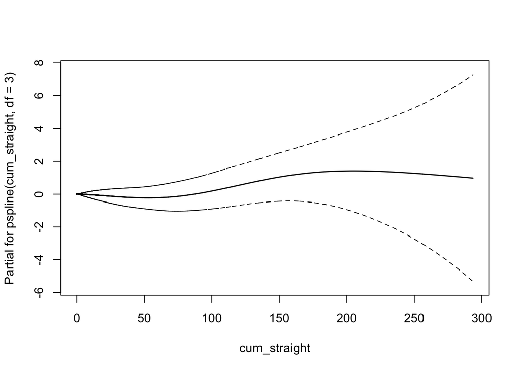

```r
# Use the built-in function to plot the spline
termplot(nhl_straight.coxph,
                 # We use term = 1 because the first term in
                 # the model is for splined straight exposure
                 term = 1,
                 se = T, col.term = 1, col.se = 1)
```

```r
# Check the terms in the model
attr(terms(nhl_soluble.coxph), "term.labels")
```

```
## [1] "`Cumulative straight`"        "pspline(cum_soluble, df = 3)"
## [3] "`Cumulative synthetic`"       "Year"
## [5] "`Year of hire`"               "Race"
## [7] "Plant"                        "Sex"
```

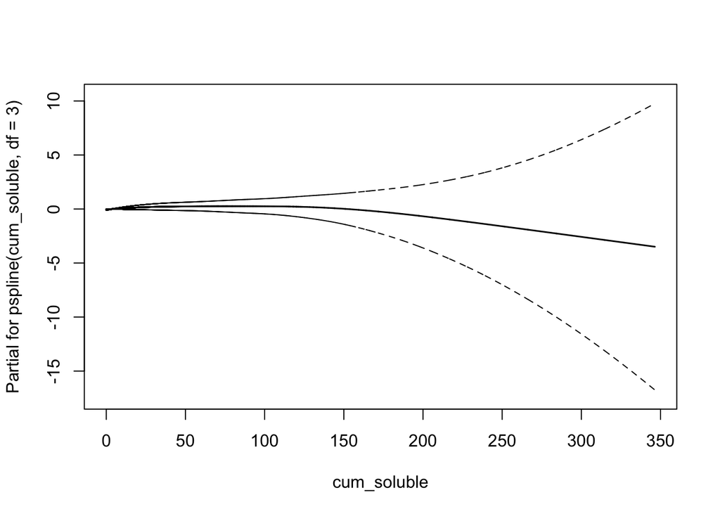

```r
# Use the built-in function to plot the spline
termplot(nhl_soluble.coxph,
                 # We use term = 2 because the first term in
                 # the model is for splined soluble exposure
                 term = 2,
                 se = T, col.term = 1, col.se = 1)
```

We can do better by extracting the values from the output of `termplot()`, subtracting the partial effect of 0 straight exposure, and exponentiating to get adjusted hazard ratios.

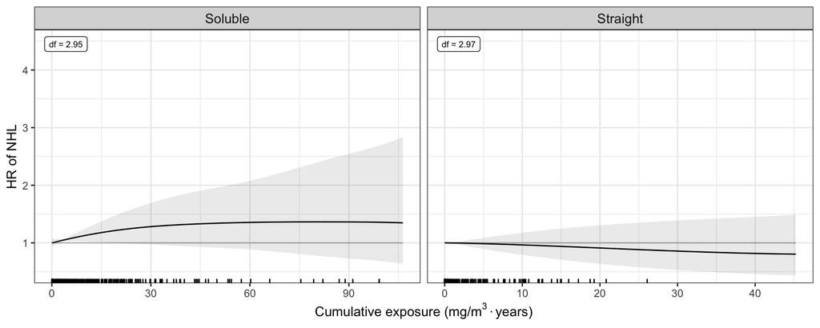

Figure 2. Adjusted hazard ratio of NHL associated with cumulative exposure to straight and soluble metalworking fluids. Missing race treated as separate category.

```r
# Make helper function for extracting termplot items
get.ggtab <- function(mod.coxph, term, mwf_ref, mwf, mwf_max.quantile) {
    # Save data used to generate the plot above
    termplot <- termplot(mod.coxph, term = term, se = T, plot = F)

    # Extract the relevant quantities
    ggtab <- data.frame(
        exposure = termplot[[1]]$x,
        `Point estimate` = termplot[[1]]$y,
        se = termplot[[1]]$se,
        Reference = mean(with(
            termplot[[1]], y[signif(x, 2) <= mwf_ref])),
        mwf_ref = mwf_ref,
        df = mod.coxph$df[term],
        check.names = F
    )
    setDT(ggtab)
    setorder(ggtab, exposure)

    # Subtract the hazard at the reference level of exposure
    ggtab[,`:=`(
        `Point estimate` = `Point estimate` - Reference
    )]

    # Set the level of exposure at which we truncate the graph
    ggtab$mwf_max <- quantile(mwf, mwf_max.quantile)

    # Thin out grid, if desired
    target_resolution <- max(50 * (max(ggtab$mwf_max) - min(mwf_ref)), 1500)
            if (nrow(ggtab) > target_resolution) {
                ggtab <- ggtab[
                    seq(1, nrow(ggtab), nrow(ggtab)/(50 * (mwf_max[1] - mwf_ref[1])))]
            }

    return(ggtab)
}

# Use helper function
nhl_straight.ggtab <- get.ggtab(
    nhl_straight.coxph, 1, 0, nhl.dat[, cum_straight[.N], studyno]$V1, 0.99)
nhl_soluble.ggtab <- get.ggtab(
    nhl_soluble.coxph, 2, 0.05, nhl.dat[, cum_soluble[.N], studyno]$V1, 0.99)

nhl.ggtab <- rbindlist(
    list("Straight" = nhl_straight.ggtab, "Soluble" = nhl_soluble.ggtab),
    idcol = "mwf"
    )[signif(exposure, 2) > mwf_ref & exposure < mwf_max]

# Rugplot data
rugplot.tab <- melt(
        nhl.dat[status == 1,.(Straight = cum_straight, Soluble = cum_soluble)],
        measure.vars = c("Straight", "Soluble"),
        value.name = "exposure",
        variable.name = "mwf"
        )
rugplot.tab$`Point estimate` <- -Inf

rugplot.tab <- merge(
    rugplot.tab,
    nhl.ggtab[,.(mwf_max = mwf_max[1]), mwf],
    by = "mwf")[exposure < mwf_max]

# Plot spline
nhl.ggtab %>% ggplot(
    aes(x = exposure, y = exp(`Point estimate`))) +
    stat_function(fun = function(x) {1}, geom = 'line',
                                color = 'grey') +
    geom_ribbon(aes(
        ymin = exp(`Point estimate` - qnorm(0.975) * se),
        ymax = exp(`Point estimate` + qnorm(0.975) * se)),
        alpha = 0.1) +
    geom_line() +
    geom_label(
        data = nhl.ggtab[,.(df = df[1], mwf_max = mwf_max[1]), mwf],
        aes(
        x = ifelse(nchar(signif(df, 3)) > 1,
                             0.04, 0.02) * (mwf_max),
        y = 4.45,
        label = paste0("df = ", signif(df, 3))),
        size = 2.5) +
    geom_rug(data = rugplot.tab, length = unit(0.015, "npc")) +
    facet_wrap(. ~ mwf, scales = "free_x") +
    coord_cartesian(ylim = c(0.5, 4.5)) +
    labs(
        x = bquote('Cumulative exposure (mg/m' ^3 %.% 'years)'),
        y = "HR of NHL") +
    theme_bw() + theme(strip.text = element_text(size = 11))
```

## Now with multiple imputation

To get the MI spline estimate, we simply repeat the analysis above $M = 5$ times, where in each iteration, we use a different imputed set for race. The code below is nearly identical to that above, except many of the actions are wrapped inside a `lapply()` function.

```r
nhl_straight_mi.coxph <- lapply(1:5, function(i = 1) {

    # Get imputed race
    dat <- merge(nhl.dat, nhl.mi_race.M5[[i]],
                             by = c("studyno", "year"),
                             all.x = T, all.y = F)
    dat[finrace %in% c(0, 9), Race := Race.impute]
    dat[,Race := factor(Race, levels = c("White", "Black"))]

    # Run Cox PH model
    nhl.coxph <- coxph(
    Surv(age.year1, age.year2, status) ~
        pspline(cum_straight, df = 3) +
        `Cumulative soluble 5` +
        `Cumulative synthetic` +
        Year +
        `Year of hire` +
        Race + Plant + Sex,
    data = dat[immortal != 1 & right.censored != 1],
    method = "efron")

    return(nhl.coxph)

})

nhl_soluble_mi.coxph <- lapply(1:5, function(i = 1) {

    # Get imputed race
    dat <- merge(nhl.dat, nhl.mi_race.M5[[i]],
                             by = c("studyno", "year"),
                             all.x = T, all.y = F)
    dat[finrace %in% c(0, 9), Race := Race.impute]
    dat[,Race := factor(Race, levels = c("White", "Black"))]

    # Run Cox PH model
    nhl.coxph <- coxph(
    Surv(age.year1, age.year2, status) ~
        `Cumulative straight` +
        pspline(cum_soluble, df = 3) +
        `Cumulative synthetic` +
        Year +
        `Year of hire` +
        Race + Plant + Sex,
    data = dat[immortal != 1 & right.censored != 1],
    method = "efron")

    return(nhl.coxph)

})

# Save output to Box
box_save(nhl_straight_mi.coxph,
                 file_name = paste0("nhl_straight_mi.coxph.rdata"),
                 dir_id = 139229852587)

# Save output to Box
box_save(nhl_soluble_mi.coxph,
                 file_name = paste0("nhl_soluble_mi.coxph.rdata"),
                 dir_id = 139229852587)
```

```r
# Load spline model output from Box
box_load(823374299857)
box_load(823390147330)
```

```r
# Give data some within-individual indexing
setorder(nhl.dat, studyno, year)
nhl.dat[immortal != 1 & right.censored != 1,
                `:=`(I = 1:(.N), N = .N), studyno]

for (mwf in c("straight", "soluble")) {
    assign(paste0("nhl_", mwf, "_mi.ggtab"),
                 lapply(1:5, function(i) {
                    # Save data used to generate the spline plots
                    nhl.termplot <- termplot(
                        get(paste0("nhl_", mwf, "_mi.coxph"))[[i]],
                        term = which(c("straight", "soluble") == mwf),
                        se = T, plot = F)

                    # Extract relevant quantities
                    nhl.ggtab <- data.frame(
                        exposure = nhl.termplot[[1]]$x,
                        `Point estimate` = nhl.termplot[[1]]$y,
                        se = nhl.termplot[[1]]$se,
                        Reference = mean(with(
                            nhl.termplot[[1]],
                            y[signif(x, 2) <= c(0, 0.05)[
                                which(c("straight", "soluble") == mwf)]
                                ])),
                        df = get(paste0("nhl_", mwf, "_mi.coxph"))[[i]]$df[
                            which(c("straight", "soluble") == mwf)
                        ],
                        mwf_ref = c(0, 0.05)[
                                which(c("straight", "soluble") == mwf)],
                        mwf_max = as.numeric(quantile(
                            unlist(nhl.dat[I == N, paste0("cum_", mwf), with = F]),
                            0.99)),
                        check.names = F
                    )
                    setDT(nhl.ggtab)
                    setorder(nhl.ggtab, exposure)

                    # Contrast to reference
                    nhl.ggtab[,`:=`(
                        `Point estimate` = `Point estimate` - Reference
                    )]

                    # Thin out grid, if desired
                    target_resolution <- max(50 * (max(nhl.ggtab$mwf_max) - min(nhl.ggtab$mwf_ref)), 1500)
                    if (nrow(nhl.ggtab) > target_resolution) {
                        nhl.ggtab <- nhl.ggtab[
                            seq(1, nrow(nhl.ggtab), nrow(nhl.ggtab)/(50 * (mwf_max[1] - mwf_ref[1])))]
                    }

                    return(nhl.ggtab)
                 }))
}
```

Now that we have a list of $M = 5$ sets of spline point estimates and standard errors, we combine them according to the formulas summarized above. The MI point estimate is simply the mean across the $M = 5$ point estimates. The variance estimate for the MI point estimate is a linear combination of the mean variance across the $M = 5$ variances and the excess variance. This must be done for every point over the fine grid of values given by the domain of the predictor.

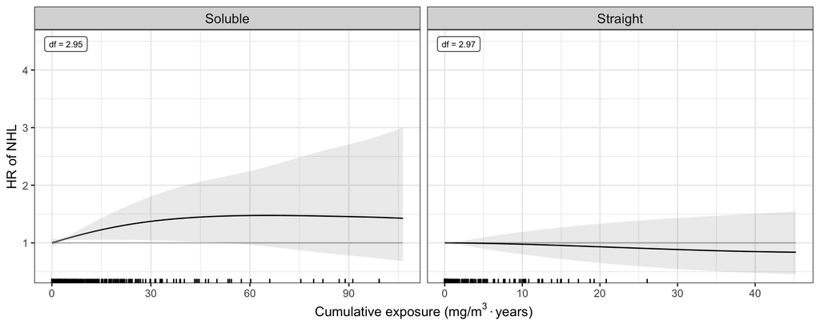

Figure 3. Adjusted hazard ratio of NHL associated with cumulative exposure to straight and soluble metalworking fluids. Missing race handled by multiple imputation

```r
# Get pooled estimates
nhl_mi.ggtab <- rbindlist(list(
    "Straight" = rbindlist(nhl_straight_mi.ggtab),
    "Soluble" = rbindlist(nhl_soluble_mi.ggtab)),
    idcol = "mwf")[, .(
    `Point estimate` = mean(`Point estimate`),
    se.pooled = sqrt(mean(se^2)),
    var.excess = sum((`Point estimate` - mean(`Point estimate`))^2/(
        5 - 1)),
    df = unique(df),
    mwf_ref = mwf_ref[1],
    mwf_max = mwf_max[1]
), by = .(exposure, mwf)]

# Calculate the standard error of the MI estimate
nhl_mi.ggtab[, se := sqrt(se.pooled^2 + (1 + 1/5) * var.excess)]
nhl_mi.ggtab[, df := mean(df), mwf]

# Plot splines
nhl_mi.ggtab[exposure > mwf_ref & exposure <= mwf_max] %>% ggplot(
    aes(x = exposure, y = exp(`Point estimate`))) +
    stat_function(fun = function(x) {1}, geom = 'line',
                                color = 'grey') +
    geom_ribbon(aes(
        ymin = exp(`Point estimate` - qnorm(0.975) * se),
        ymax = exp(`Point estimate` + qnorm(0.975) * se)),
        alpha = 0.1) +
    geom_line() +
    geom_rug(data = rugplot.tab, length = unit(0.015, "npc")) +
    geom_label(data = nhl_mi.ggtab[,.(
        df = df[1], mwf_max = mwf_max[1]
    ), mwf], aes(
        x = 0.04 * mwf_max,
        y = 4.45,
        label = paste0("df = ", signif(df, 3))),
        size = 2.5) +
    coord_cartesian(ylim = c(0.5, 4.5)) +
    facet_wrap(. ~ mwf, scales = "free_x") +
    labs(
        x = bquote('Cumulative exposure (mg/m' ^3 %.% 'years)'),
        y = "HR of NHL") +
    theme_bw() + theme(strip.text = element_text(size = 11))
```

## Citations

Hurvich, Clifford M., and Chih-Ling Tsai. 1991. “Bias of the corrected AIC criterion for underfitted regression and time series models.” *Biometrika* 78 (3): 499–509. https://doi.org/10.1093/biomet/78.3.499.

Murray, Jared S, and others. 2018. “Multiple Imputation: A Review of Practical and Theoretical Findings.” *Statistical Science* 33 (2): 142–59.

Thernau, Terry. 2021. *Spline Terms in a Cox Model*. https://cran.r-project.org/web/packages/survival/vignettes/splines.pdf.